# ipm lebih baru

G1401231083 - Gafin Khalifa Nalya

2025-09-02

## Packages

```r
library(readxl)
library(nlme)
library(orcutt)
library(dynlm)
library(dplyr)
library(TTR)
library(forecast)
library(lmtest) #digunakan untuk uji formal pendeteksian autokorelasi
library(orcutt) #untuk membuat model regresi Cochrane-Orcutt
library(HoRM)
```

## Input Data

```r
ipm <- read_excel("C:/Users/Gafin K Nalya/Documents/ipb/STK/SEM 5/MPDW/MPDW/Pertemuan 2/ipm bandung.xlsx")
head(ipm)
```

```
## # A tibble: 6 × 2
##   Tahun   IPM
##   <dbl> <dbl>
## 1  2010  76.6
## 2  2011  77.2
## 3  2012  77.5
## 4  2013  78.2
## 5  2014  78.8
## 6  2015  79.5
```

## Eksplorasi Data

### Menjadikan time-series

```r
data.ts <- ts(ipm$IPM)
data.ts
```

```
## Time Series:
## Start = 1
## End = 14
## Frequency = 1
##  [1] 76.61 77.15 77.53 78.20 78.81 79.47 80.13 80.66 81.27 81.85 81.90 82.17
## [13] 82.58 82.96
```

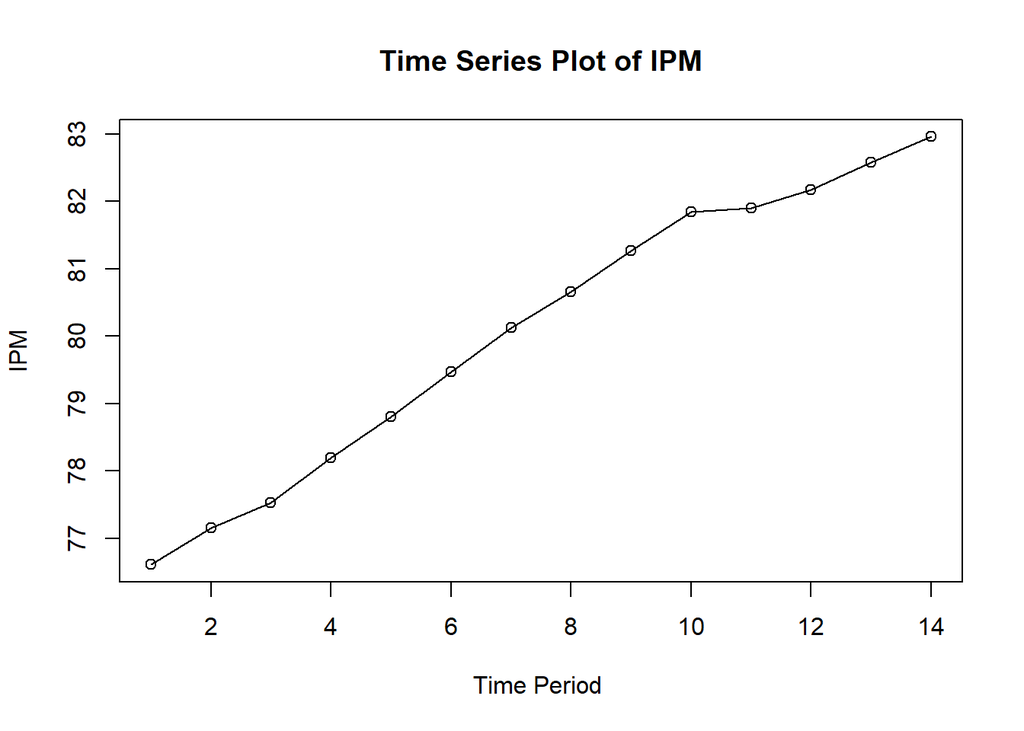

```r
ts.plot(data.ts, xlab="Time Period ", ylab="IPM", main= "Time Series Plot of IPM")
points(data.ts)
```

Ada tren -> DMA dan DES

```r
dt.sma <- SMA(data.ts, n=3)
dma <- SMA(dt.sma, n = 3)
At <- 2*dt.sma - dma
Bt <- 2/(3-1)*(dt.sma - dma)
dt.dma<- At+Bt
dt.ramal<- c(NA, dt.dma)

t = 1:5
f = c()

for (i in t) {
  f[i] = At[length(At)] + Bt[length(Bt)]*(i)
}

dt.gab <- cbind(aktual = c(data.ts,rep(NA,5)),
                pemulusan1 = c(dt.sma,rep(NA,5)),
                pemulusan2 = c(dt.dma, rep(NA,5)),
                At = c(At, rep(NA,5)),
                Bt = c(Bt,rep(NA,5)),
                ramalan = c(dt.ramal, f[-1]))
dt.gab
```

```
##       aktual pemulusan1 pemulusan2       At        Bt  ramalan
##  [1,]  76.61         NA         NA       NA        NA       NA
##  [2,]  77.15         NA         NA       NA        NA       NA
##  [3,]  77.53   77.09667         NA       NA        NA       NA
##  [4,]  78.20   77.62667         NA       NA        NA       NA
##  [5,]  78.81   78.18000   79.27111 78.72556 0.5455556       NA
##  [6,]  79.47   78.82667   80.05778 79.44222 0.6155556 79.27111
##  [7,]  80.13   79.47000   80.75889 80.11444 0.6444444 80.05778
##  [8,]  80.66   80.08667   81.33778 80.71222 0.6255556 80.75889
##  [9,]  81.27   80.68667   81.89778 81.29222 0.6055556 81.33778
## [10,]  81.85   81.26000   82.42444 81.84222 0.5822222 81.89778
## [11,]  81.90   81.67333   82.60667 82.14000 0.4666667 82.42444
## [12,]  82.17   81.97333   82.64889 82.31111 0.3377778 82.60667
## [13,]  82.58   82.21667   82.74111 82.47889 0.2622222 82.64889
## [14,]  82.96   82.57000   83.20333 82.88667 0.3166667 82.74111
## [15,]     NA         NA         NA       NA        NA 83.20333
## [16,]     NA         NA         NA       NA        NA 83.52000
## [17,]     NA         NA         NA       NA        NA 83.83667
## [18,]     NA         NA         NA       NA        NA 84.15333
## [19,]     NA         NA         NA       NA        NA 84.47000
```

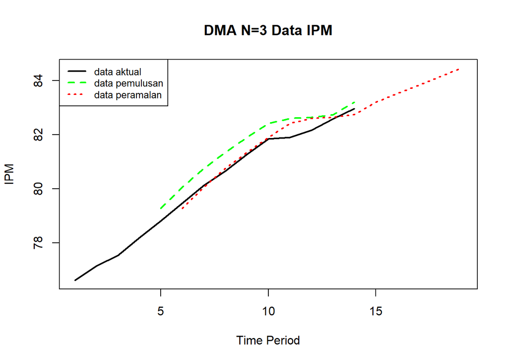

```r
#Plot time series
ts.plot(dt.gab[, c(1,3,6)],
        xlab = "Time Period",
        ylab = "IPM",
        main = "DMA N=3 Data IPM",
        col = c("black", "green", "red"),
        lty = 1:3, lwd = 2)

legend("topleft",
       legend = c("data aktual", "data pemulusan", "data peramalan"),
       col = c("black", "green", "red"),
       lty = 1:3, lwd = 2, cex = 0.8)
```

Menghitung akurasi DMA

```r
#Menghitung nilai keakuratan
error.dma = data.ts-dt.ramal[1:length(data.ts)]
SSE.dma = sum(error.dma[6:length(data.ts)]^2)
MSE.dma = mean(error.dma[6:length(data.ts)]^2)
MAPE.dma = mean(abs((error.dma[6:length(data.ts)]/data.ts[6:length(data.ts)])*100))

akurasi.dma <- matrix(c(SSE.dma, MSE.dma, MAPE.dma))
row.names(akurasi.dma)<- c("SSE", "MSE", "MAPE")
colnames(akurasi.dma) <- c("Akurasi m = 3")
akurasi.dma
```

```
##      Akurasi m = 3
## SSE     0.57980617
## MSE     0.06442291
## MAPE    0.23597846
```

Menggunakan metode Double Exponential Smoothing

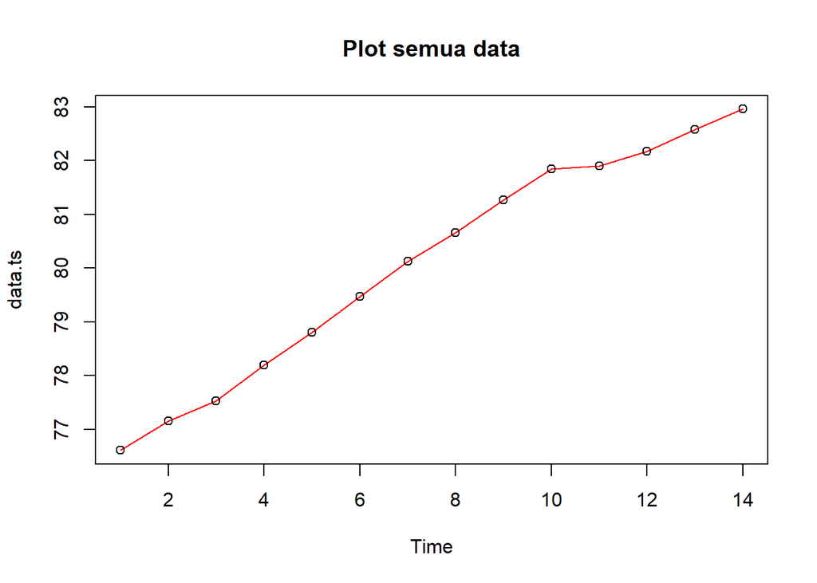

```r
#membagi training dan testing
training<-ipm[1:11,2]
testing<-ipm[12:14,2]

#data time series
training.ts<-ts(training)
testing.ts<-ts(testing,start=12)

#eksplorasi data
plot(data.ts, col="red",main="Plot semua data")
points(data.ts)
```

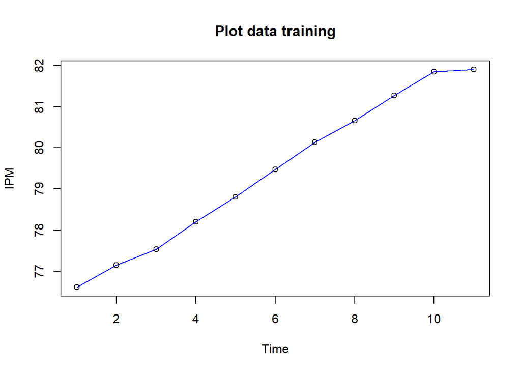

```r
plot(training.ts, col="blue",main="Plot data training")
points(training.ts)
```

Cari lambda dan gamma optimum. Dapat dilihat pada smoothing parameters alpha untuk nilai lambda dan bedta beta untuk nilai gamma

```r
#Lamda dan gamma optimum
des.opt<- HoltWinters(training.ts, gamma = FALSE)
des.opt
```

```
## Holt-Winters exponential smoothing with trend and without seasonal component.
##
## Call:
## HoltWinters(x = training.ts, gamma = FALSE)
##
## Smoothing parameters:
##  alpha: 0.8775541
##  beta : 0
##  gamma: FALSE
##
## Coefficients:
##       [,1]
## a 81.95927
## b  0.54000
```

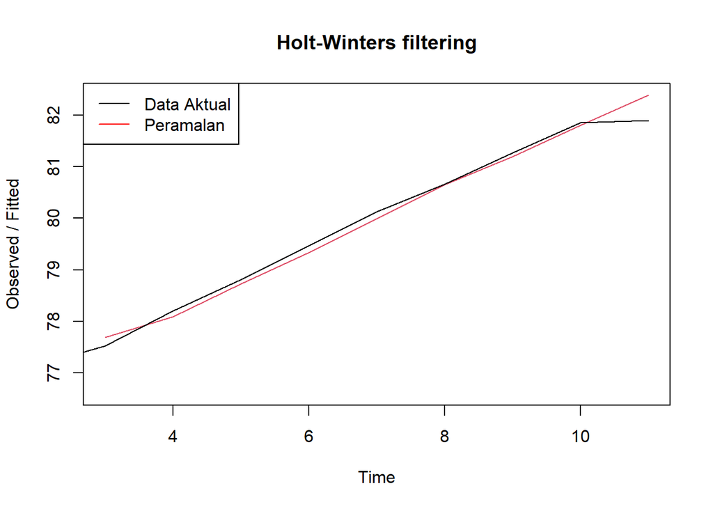

```r
plot(des.opt)
legend("topleft", c("Data Aktual", "Peramalan"), col = c("black", "red"),
       lty = c(1,1))
```

```r
#ramalan
ramalandesopt<- forecast(des.opt, h=5)
ramalandesopt
```

```
##    Point Forecast    Lo 80    Hi 80    Lo 95    Hi 95
## 12       82.49927 82.24234 82.75620 82.10632 82.89221
## 13       83.03927 82.69743 83.38111 82.51647 83.56206
## 14       83.57927 83.16977 83.98877 82.95299 84.20555
## 15       84.11927 83.65180 84.58674 83.40433 84.83420
## 16       84.65927 84.14026 85.17827 83.86552 85.45302
```

```r
accuracy(ramalandesopt)
```

```
##                        ME      RMSE       MAE         MPE      MAPE     MASE
## Training set -0.006423312 0.1891291 0.1366968 -0.00687341 0.1703234 0.258406
##                    ACF1
## Training set 0.01592968
```

Cari akurasi metode DES

```r
ssedes.train<-des.opt$SSE
msedes.train<-ssedes.train/length(training.ts)
sisaandes<-ramalandesopt$residuals
head(sisaandes)
```

```
## Time Series:
## Start = 1
## End = 6
## Frequency = 1
##                x
## [1,]          NA
## [2,]          NA
## [3,] -0.16000000
## [4,]  0.11040866
## [5,]  0.08351909
## [6,]  0.13022657
```

```r
mapedes.train <- sum(abs(sisaandes[3:length(training.ts)]/training.ts[3:length(training.ts)])*100)/length(training.ts)

akurasides.opt <- matrix(c(ssedes.train,msedes.train,mapedes.train))
row.names(akurasides.opt)<- c("SSE", "MSE", "MAPE")
colnames(akurasides.opt) <- c("Akurasi lamda dan gamma optimum")
akurasides.opt
```

```
##      Akurasi lamda dan gamma optimum
## SSE                       0.32192848
## MSE                       0.02926623
## MAPE                      0.13935552
```

```r
#Akurasi data testing
selisihdesopt<-ramalandesopt$mean-testing.ts
selisihdesopt
```

```
## Time Series:
## Start = 12
## End = 14
## Frequency = 1
##      testing.ts
## [1,]  0.3292688
## [2,]  0.4592688
## [3,]  0.6192688
```

```r
SSEtestingdesopt<-sum(selisihdesopt^2)
SSEtestingdesopt<-SSEtestingdesopt/length(testing.ts)
MAPEtestingdesopt<-sum(abs(selisihdesopt/testing.ts)*100)/length(testing.ts)

akurasiDesTesting <- matrix(c(SSEtestingdesopt,SSEtestingdesopt,MAPEtestingdesopt))
row.names(akurasiDesTesting)<- c("SSE", "MSE", "MAPE")
colnames(akurasiDesTesting) <- c("Akurasi lamda dan gamma optimum")
akurasiDesTesting
```

```
##      Akurasi lamda dan gamma optimum
## SSE                        0.2342798
## MSE                        0.2342798
## MAPE                       0.5677778
```

Perbandingan akurasi antar kedua metode

```r
cbind(akurasi.dma, akurasides.opt)
```

```
##      Akurasi m = 3 Akurasi lamda dan gamma optimum
## SSE     0.57980617                      0.32192848
## MSE     0.06442291                      0.02926623
## MAPE    0.23597846                      0.13935552
```

Metode DES lebih baik dari DMA karena nilai SSE, MSE, dan MAPE yang lebih kecil.

## Regresi

### Eksplorasi

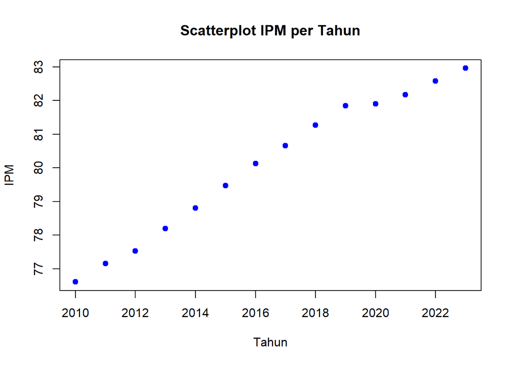

```r
plot(ipm$Tahun, ipm$IPM,
     main = "Scatterplot IPM per Tahun",
     xlab = "Tahun",
     ylab = "IPM",
     pch = 19,       # bentuk titik (19 = bulat solid)
     col = "blue")   # warna titik
```

```r
cor(ipm$Tahun,ipm$IPM)
```

```
## [1] 0.990885
```

Membuat model regresi

```r
model<- lm(IPM~Tahun, data = ipm)
summary(model)
```

```
##
## Call:
## lm(formula = IPM ~ Tahun, data = ipm)
##
## Residuals:
##     Min      1Q  Median      3Q     Max
## -0.4331 -0.2009 -0.0636  0.2537  0.4882
##
## Coefficients:
##               Estimate Std. Error t value Pr(>|t|)
## (Intercept) -943.97963   40.19005  -23.49 2.12e-11 ***
## Tahun          0.50785    0.01993   25.48 8.12e-12 ***
## ---
## Signif. codes:  0 '***' 0.001 '**' 0.01 '*' 0.05 '.' 0.1 ' ' 1
##
## Residual standard error: 0.3006 on 12 degrees of freedom
## Multiple R-squared:  0.9819, Adjusted R-squared:  0.9803
## F-statistic: 649.3 on 1 and 12 DF,  p-value: 8.12e-12
```

Uji terhadap sisaan

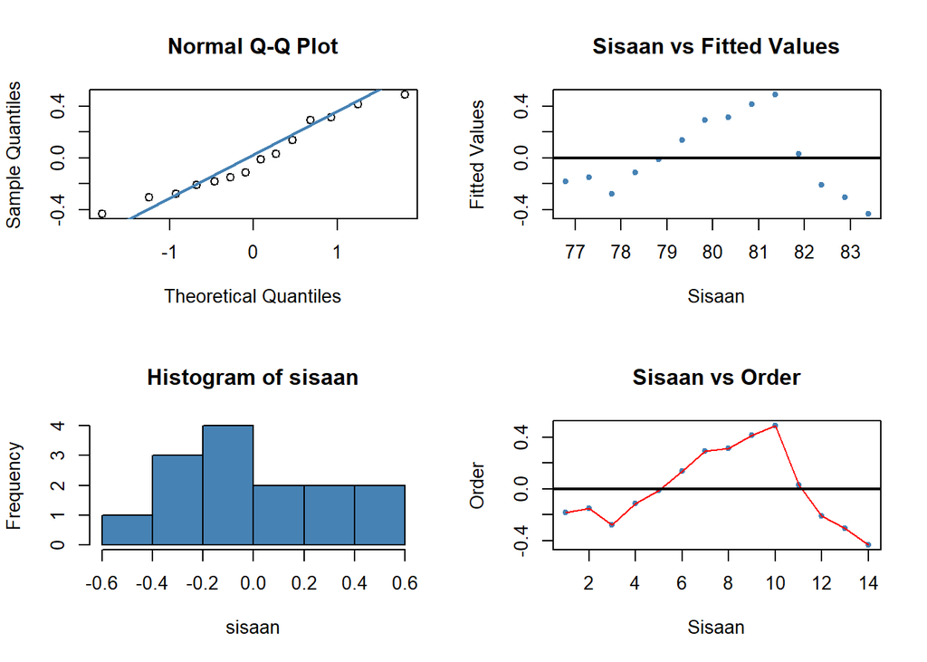

```r
#sisaan dan fitted value
sisaan<- residuals(model)
fitValue<- predict(model)

#Diagnostik dengan eksploratif
par(mfrow = c(2,2))
qqnorm(sisaan)
qqline(sisaan, col = "steelblue", lwd = 2)
plot(fitValue, sisaan, col = "steelblue", pch = 20, xlab = "Sisaan", ylab = "Fitted Values", main = "Sisaan vs Fitted Values")
abline(a = 0, b = 0, lwd = 2)
hist(sisaan, col = "steelblue")
plot(seq(1,14,1), sisaan, col = "steelblue", pch = 20, xlab = "Sisaan", ylab = "Order", main = "Sisaan vs Order")
lines(seq(1,14,1), sisaan, col = "red")
abline(a = 0, b = 0, lwd = 2)
```

```r
#Melihat Sisaan Menyebar Normal/Tidak
#H0: sisaan mengikuti sebaran normal
#H1: sisaan tidak mengikuti sebaran normal
shapiro.test(sisaan)
```

```
##
##  Shapiro-Wilk normality test
##
## data:  sisaan
## W = 0.94759, p-value = 0.524
```

```r
ks.test(sisaan, "pnorm", mean=mean(sisaan), sd=sd(sisaan))
```

```
##
##  Exact one-sample Kolmogorov-Smirnov test
##
## data:  sisaan
## D = 0.15434, p-value = 0.8439
## alternative hypothesis: two-sided
```

Sisaan berdistribusi normal

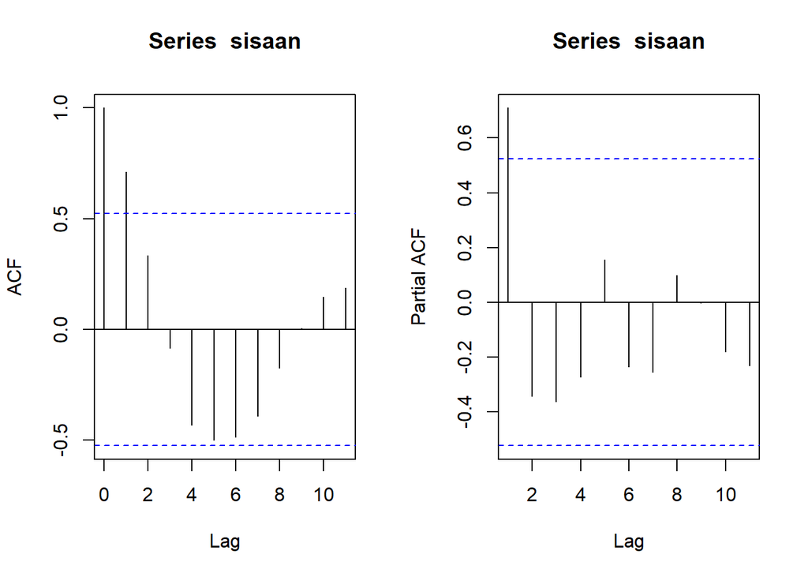

```r
par(mfrow = c(1,2))
acf(sisaan)
pacf(sisaan)
```

```r
#Deteksi autokorelasi dengan uji-Durbin Watson
#H0: tidak ada autokorelasi
#H1: ada autokorelasi
dwtest(model)
```

```
##
##  Durbin-Watson test
##
## data:  model
## DW = 0.37684, p-value = 1.255e-06
## alternative hypothesis: true autocorrelation is greater than 0
```

Ada autokorelasi

## Penanganan Autokorelasi

### Cochrane-Orcutt

```r
#Penanganan Autokorelasi Cochrane-Orcutt
modelCO<-cochrane.orcutt(model)
modelCO
```

```
## Cochrane-orcutt estimation for first order autocorrelation
##
## Call:
## lm(formula = IPM ~ Tahun, data = ipm)
##
##  number of interaction: 100
##  rho 0.919315
##
## Durbin-Watson statistic
## (original):    0.37684 , p-value: 1.255e-06
## (transformed): NA , p-value: NA
##
##  coefficients:
## [1] NA
```

```r
rho<- modelCO$rho
rho
```

```
## [1] 0.9193152
```

Hubungan DW test dengan kegagalan Cochrane–Orcutt

DW test → autokorelasi sangat kuat (ρ ≈ 0.92)

Hasil DW = 0.3768 jauh di bawah 2 → ini menunjukkan autokorelasi positif ekstrem.

Estimasi CO (rho 0.919315) juga mengonfirmasi hal ini.

Cochrane–Orcutt bekerja dengan iterasi

CO memperkirakan ρ, lalu mentransformasi data, lalu menghitung ulang model, dan diulang sampai stabil.

Jika ρ mendekati 1 (unit root / hampir non-stasioner), proses ini jadi tidak stabil → algoritma “loncat-loncat” dan tidak menemukan titik konvergen.

Apa yang terjadi di outputmu?

Iterasi sudah sampai 100 kali.

ρ tetap sekitar 0.919, belum stabil.

Karena gagal konvergen, koefisien hasil transformasi jadi NA.

```r
#Transformasi Manual
ipm.trans<- ipm$IPM[-1]-ipm$IPM[-14]*rho
tahun.trans<- ipm$Tahun[-1]-ipm$Tahun[-14]*rho
modelCOmanual<- lm(ipm.trans~tahun.trans)
summary(modelCOmanual)
```

```
##
## Call:
## lm(formula = ipm.trans ~ tahun.trans)
##
## Residuals:
##      Min       1Q   Median       3Q      Max
## -0.33491 -0.09946  0.04275  0.12327  0.16699
##
## Coefficients:
##             Estimate Std. Error t value Pr(>|t|)
## (Intercept) -30.9844    24.8313  -1.248    0.238
## tahun.trans   0.2317     0.1517   1.527    0.155
##
## Residual standard error: 0.1652 on 11 degrees of freedom
## Multiple R-squared:  0.1749, Adjusted R-squared:  0.09989
## F-statistic: 2.332 on 1 and 11 DF,  p-value: 0.155
```

```r
dwtest(modelCOmanual)
```

```
##
##  Durbin-Watson test
##
## data:  modelCOmanual
## DW = 1.5081, p-value = 0.09737
## alternative hypothesis: true autocorrelation is greater than 0
```

```r
#Mencari Penduga Koefisien Regresi setelah Transformasi ke Persamaan Awal
b0bintang <- modelCOmanual$coefficients[-2]
b0 <- b0bintang/(1-rho)
b1 <- modelCOmanual$coefficients[-1]
b0
```

```
## (Intercept)
##   -384.0179
```

```r
b1
```

```
## tahun.trans
##   0.2316825
```

### Hildreth-Lu

```r
#Penanganan Autokorelasi Hildreth lu
# Hildreth-Lu
hildreth.lu.func<- function(r, model){
  x <- model.matrix(model)[,-1]
  y <- model.response(model.frame(model))
  n <- length(y)
  t <- 2:n
  y <- y[t]-r*y[t-1]
  x <- x[t]-r*x[t-1]

  return(lm(y~x))
}

#Pencarian rho yang meminimumkan SSE
r <- c(seq(0.1,0.9, by= 0.1))
tab <- data.frame("rho" = r, "SSE" = sapply(r, function(i){deviance(hildreth.lu.func(i, model))}))
round(tab, 4)
```

```
##   rho    SSE
## 1 0.1 0.8916
## 2 0.2 0.7595
## 3 0.3 0.6441
## 4 0.4 0.5454
## 5 0.5 0.4632
## 6 0.6 0.3978
## 7 0.7 0.3489
## 8 0.8 0.3167
## 9 0.9 0.3011
```

ρ yang menghasilkan SSE minimum ketika 0.9. Namun masih belum teliti.

```r
#Rho optimal di sekitar 0.4
rOpt <- seq(0.9,1, by= 0.001)
tabOpt <- data.frame("rho" = rOpt, "SSE" = sapply(rOpt, function(i){deviance(hildreth.lu.func(i, model))}))
head(tabOpt[order(tabOpt$SSE),])
```

```
##      rho       SSE
## 45 0.944 0.2995323
## 44 0.943 0.2995325
## 46 0.945 0.2995337
## 43 0.942 0.2995344
## 47 0.946 0.2995368
## 42 0.941 0.2995379
```

SSE minimum di rho = 0.944

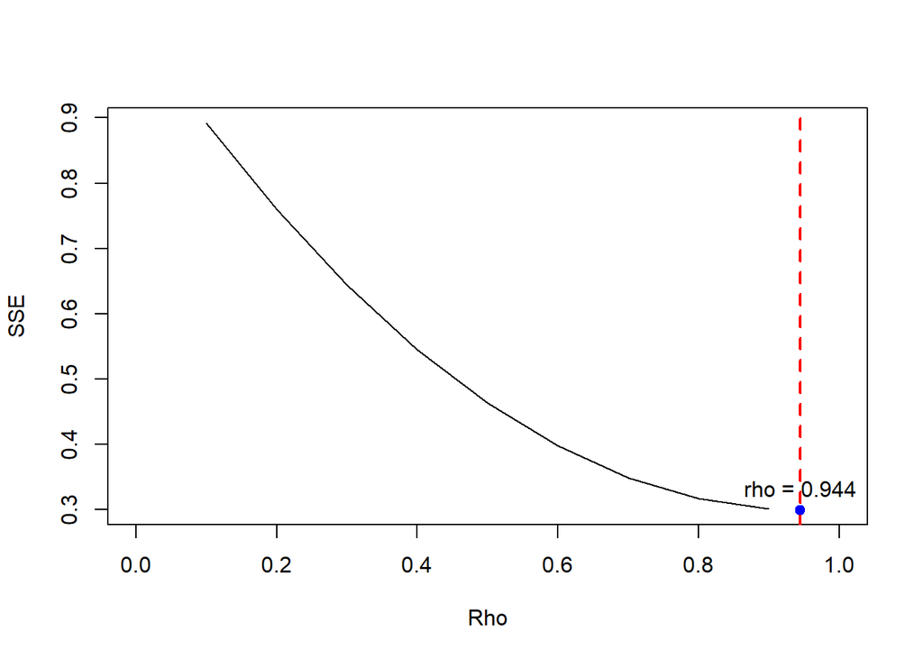

```r
# cari titik optimum
rho.opt <- tabOpt[which.min(tabOpt$SSE), "rho"]
sse.opt <- min(tabOpt$SSE)

# plot dengan batas x sampai 1
plot(tab$SSE ~ tab$rho, type = "l",
     xlab = "Rho", ylab = "SSE",
     xlim = c(0, 1))   # atur batas sumbu X

# garis vertikal di rho optimum
abline(v = rho.opt, lty = 2, col = "red", lwd = 2)

# titik di lokasi optimum
points(rho.opt, sse.opt, col = "blue", pch = 19)

# label di atas titik
text(x = rho.opt, y = sse.opt,
     labels = paste0("rho = ", round(rho.opt, 3)),
     pos = 3, cex = 1.0)
```

Perhitungan yang dilakukan aplikasi R menunjukkan bahwa nilai ρ optimum, yaitu saat SSE terkecil terdapat pada nilai ρ=0.944 . Hal tersebut juga ditunjukkan pada plot. Selanjutnya, model dapat didapatkan dengan mengevaluasi nilai ρ ke dalam fungsi hildreth.lu.func, serta dilanjutkan dengan pengujian autokorelasi dengan uji Durbin-Watson. Namun, setelah pengecekan tersebut tidak lupa koefisien regresi tersebut digunakan untuk transformasi balik. Persamaan hasil transformasi itulah yang menjadi persamaan sesungguhnya.

```r
#Model terbaik
modelHL <- hildreth.lu.func(0.944, model)
summary(modelHL)
```

```
##
## Call:
## lm(formula = y ~ x)
##
## Residuals:
##      Min       1Q   Median       3Q      Max
## -0.34491 -0.09663  0.04517  0.12358  0.15995
##
## Coefficients:
##             Estimate Std. Error t value Pr(>|t|)
## (Intercept)  -6.7251    24.8777   -0.27    0.792
## x             0.1026     0.2184    0.47    0.648
##
## Residual standard error: 0.165 on 11 degrees of freedom
## Multiple R-squared:  0.01967,    Adjusted R-squared:  -0.06945
## F-statistic: 0.2207 on 1 and 11 DF,  p-value: 0.6477
```

```r
cat("y = ", coef(modelHL)[1]/(1-0.341), "+", coef(modelHL)[2],"x", sep = "")
```

```
## y = -10.20507+0.102606x
```

```r
dwtest(modelHL)
```

```
##
##  Durbin-Watson test
##
## data:  modelHL
## DW = 1.5459, p-value = 0.1111
## alternative hypothesis: true autocorrelation is greater than 0
```

Tidak ada autokorelasi pada taraf nyata 5%.

```r
#Perbandingan
sseModelawal <- anova(model)$`Sum Sq`[-1]
sseModelCO <- anova(modelCOmanual)$`Sum Sq`[-1]
sseModelHL <- anova(modelHL)$`Sum Sq`[-1]
mseModelawal <- sseModelawal/length(ipm)
mseModelCO <- sseModelCO/length(ipm)
mseModelHL <- sseModelHL/length(ipm)
akurasi <- matrix(c(sseModelawal,sseModelCO,sseModelHL,
                    mseModelawal,mseModelCO,mseModelHL),nrow=2,ncol=3,byrow = T)
colnames(akurasi) <- c("Model Awal", "Model Cochrane-Orcutt", "Model Hildreth-Lu")
row.names(akurasi) <- c("SSE","MSE")
akurasi
```

```
##     Model Awal Model Cochrane-Orcutt Model Hildreth-Lu
## SSE  1.0844303             0.3000238         0.2995323
## MSE  0.5422152             0.1500119         0.1497661
```

Model Cochrane-Orcutt dan Hildreth-Lu tidak berbeda jauh karena nilai SSE dan MSE yang hampir sama, tetapi model Hildreth-Lu lebih kecil dengan sangat sedikit.